# Advanced Plotting and Polishing Graphics

Di Cook, Eric Hare  
5/15-18/2015

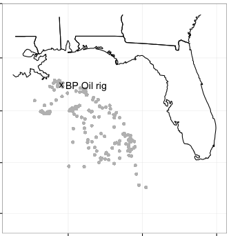

California Dreaming - ASA Travelling Workshop

### Back to the Oscars

```r
oscars <- read.csv("data/oscars.csv", stringsAsFactors=FALSE)
acting <- subset(oscars, AwardCategory=="Actor")
actcountry <- data.frame(table(acting$Country))
colnames(actcountry)[1] <- "Country"
head(actcountry)
```

```
    Country Freq
1 Australia    4
2   Austria    4
3   Belgium    1
4  Cambodia    1
5    Canada    6
6    France    4
```

### Adding maps

```r
library(ggplot2)
library(maps)
library(ggmap)
library(rworldmap)
mc <- joinCountryData2Map(actcountry, joinCode = "NAME",
    nameJoinColumn = "Country", mapResolution = "low")
```

```
26 codes from your data successfully matched countries in the map
0 codes from your data failed to match with a country code in the map
218 codes from the map weren't represented in your data
```

### Now draw

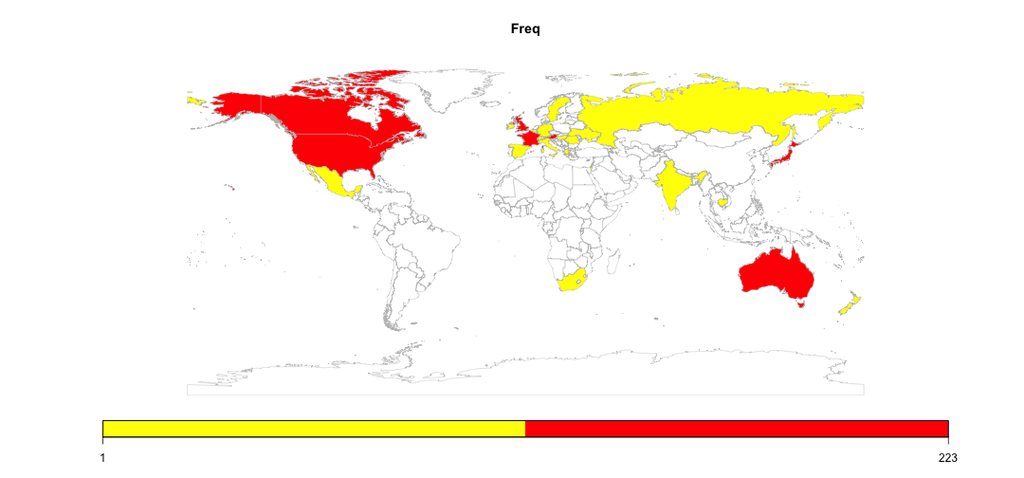

```r
mapCountryData(mc, nameColumnToPlot="Freq")
```

### And tweak

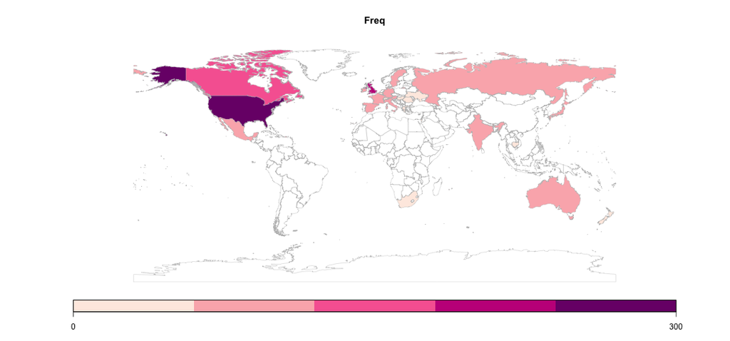

```r
library(RColorBrewer)
clrs <- brewer.pal(5,'RdPu')
mapCountryData(mc, nameColumnToPlot="Freq", catMethod=c(0,1,5, 50, 100, 300),
               colourPalette=clrs)
```

### Maps more generally

A map is really just a bunch of latitude longitude points…

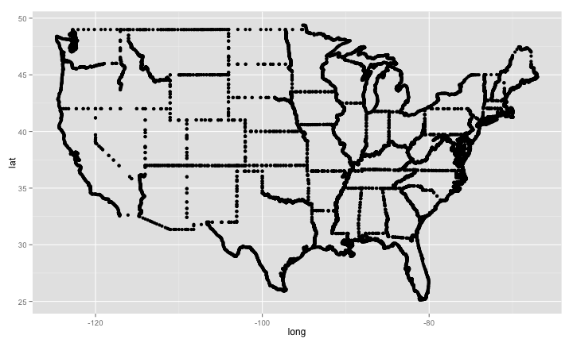

```r
qplot(long, lat, geom="point", data=states)
```

### Maps more generally

… that are connected with lines in a very specific order.

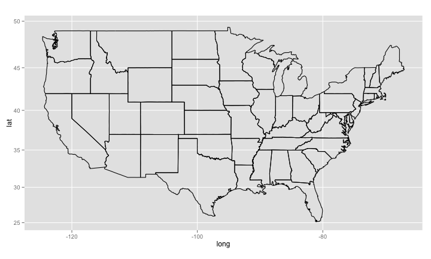

```r
qplot(long, lat, geom="path", data=states, group=group) + coord_map()
```

`coord_map` sets the appropriate lat/long aspect ratio

### Basic map data

What needs to be in the data set in order to plot a basic map?

- Need latitude/longitude points for all map boundaries
- Need to know which boundary group all lat/long points belong
- Need to know the order to connect points within each group

### Data for building basic state map

Our `states` data has all necessary information

```r
states <- map_data("state")
head(states)
```

```
       long      lat group order  region subregion
1 -87.46201 30.38968     1     1 alabama      <NA>
2 -87.48493 30.37249     1     2 alabama      <NA>
3 -87.52503 30.37249     1     3 alabama      <NA>
4 -87.53076 30.33239     1     4 alabama      <NA>
5 -87.57087 30.32665     1     5 alabama      <NA>
6 -87.58806 30.32665     1     6 alabama      <NA>
```

### Incorporating information about states

Want to incorporate additional information into the plot:

- Add other geographic information by adding geometric layers to the plot
- Add non-geopgraphic information by altering the fill color for each state
- Use `geom=''polygon''` to treat states as solid shapes to add color
- Incorporate numeric information using color shade or intensity
- Incorporate categorical informaion using color hue

### Categorical information using hue

If a categorical variable is assigned as the fill color then `qplot` will assign different hues for each category

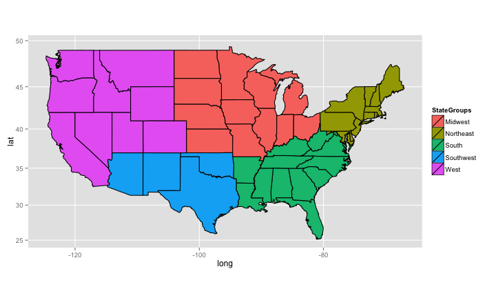

```r
qplot(long, lat, geom="polygon", data=states.class.map, group=group,
      fill=StateGroups, colour=I("black")) + coord_map()
```

### Numerical information using shade and intensity

To show how was can add numerical information to map plots we will use the BRFSS data

- Behavioral Risk Factor Surveillance System
- 2008 telephone survey run by the Center for Disease Control (CDC)
- Ask a variety of questions related to health and wellness
- Cleaned data with state aggregated values posted on website

### BRFSS data aggregated by state

```r
head(states.stats)
```

```
  state.name   avg.wt avg.qlrest2   avg.ht  avg.bmi avg.drnk
1    alabama 180.7247    9.051282 168.0310 29.00222 2.333333
2     alaska 189.2756    8.380952 172.0992 28.90572 2.323529
3    arizona 169.6867    5.770492 168.2616 27.04900 2.406897
4   arkansas 177.3663    8.226619 168.7958 28.02310 2.312500
5 california 170.0464    6.847751 168.1314 27.23330 2.170000
6   colorado 167.1702    8.134715 169.6110 26.16552 1.970501
```

### Numerical Information Using Shade and Intensity

Average number of days in the last 30 days of insufficient sleep by state

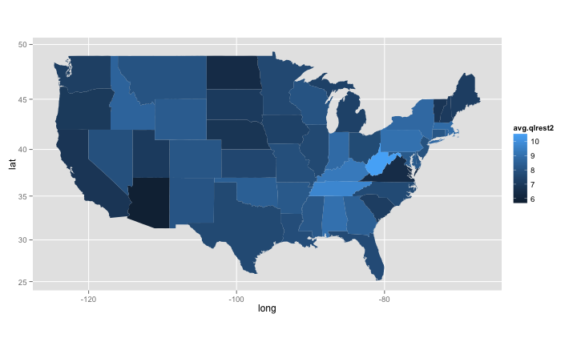

```r
states.map <- merge(states, states.stats, by.x="region", by.y="state.name", all.x=T)
qplot(long, lat, geom="polygon", data=states.map, group=group, fill=avg.qlrest2) + coord_map()
```

### BRFSS Data Aggregated by State and Gender

```r
states.sex.map <- merge(states, states.sex.stats, by.x="region", by.y="state.name", all.x=T)
head(states.sex.stats)
```

```
  state.name SEX   avg.wt avg.qlrest2   avg.ht  avg.bmi avg.drnk    sex
1    alabama   1 198.8936    8.648936 177.5729 28.50714 3.033333   Male
2    alabama   2 173.0315    9.224771 163.9956 29.21280 2.041667 Female
3     alaska   1 203.3919    7.236111 178.3896 28.91494 2.487179   Male
4     alaska   2 169.5660    9.907407 163.1296 28.89286 2.103448 Female
5    arizona   1 191.3739    5.163793 177.1724 27.63152 2.814286   Male
6    arizona   2 156.2054    6.142857 162.7043 26.67683 2.026667 Female
```

### Adding Numerical Information

Average number of alcoholic drinks per day by state and gender

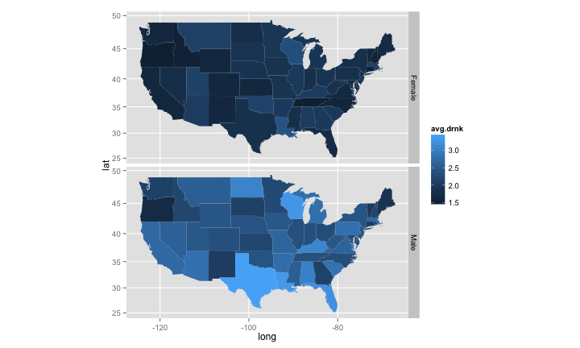

```r
qplot(long, lat, geom="polygon", data=states.sex.map,
  group=group, fill=avg.drnk) +
  coord_map() + facet_grid(sex ~ .)
```

### Your turn

- Use `merge` to combine child healthcare data with maps information
- Then use `qplot` to create a map of child healthcare undercoverage rate by state

### Cleaning up your maps

Use ggplot2 options to clean up your map!

- Adding Titles `+ ggtitle(...)`
- Might want a plain white background `+ theme_bw()`
- Extremely familiar geography may eliminate need for latitude and longitude axes `+ theme(...)`
- Want to customize color gradient `+ scale_fill_gradient2(...)`
- Keep aspect ratios correct `+ coord_map()`

### Cleaning up your maps

```r
new_theme_empty <- theme_bw()
new_theme_empty$line <- element_blank()
new_theme_empty$rect <- element_blank()
new_theme_empty$strip.text <- element_blank()
new_theme_empty$axis.text <- element_blank()
new_theme_empty$axis.title <- element_blank()
new_theme_empty$plot.margin <- structure(c(0, 0, -1, -1),
      unit = "lines", valid.unit = 3L, class = "unit")
```

```r
qplot(long, lat, geom="polygon", data=states.map, group=group, fill=avg.drnk) +
  coord_map() +  theme_bw() +
  scale_fill_gradient2(limits=c(1.5, 3),low="lightgray",high="black") +
  new_theme_empty +
  ggtitle("Average Number of Alcoholic Beverages Consumed Per Day")
```

### Show it

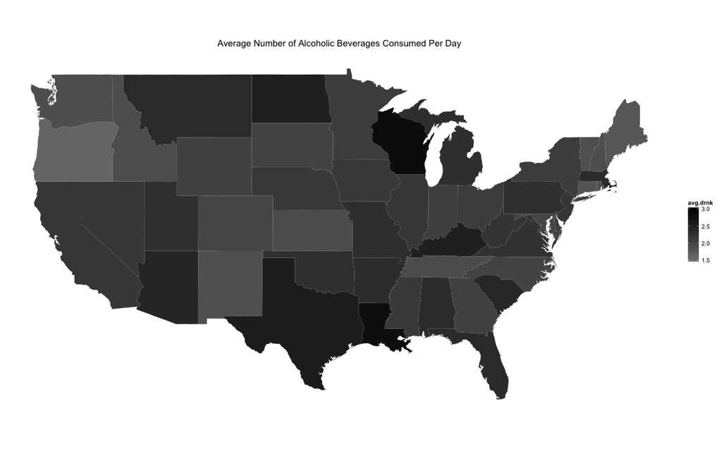

### Your turn

Polish the look of your map of child healthcare undercoverage rate by state!

### Putting it together

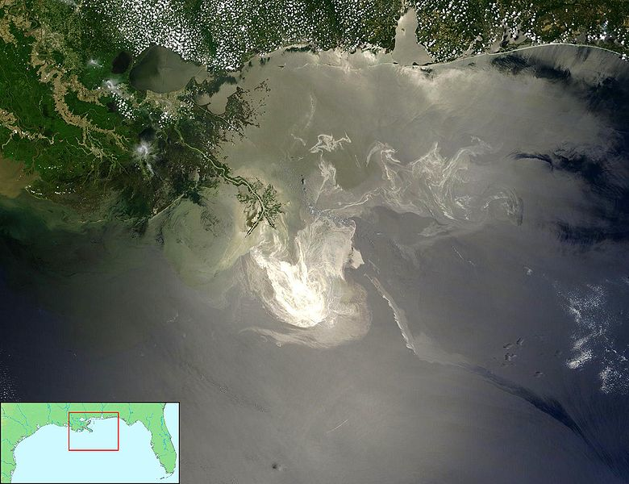

BP Oil Spill May 24 2010 catastrophic environmental disaster in the Gulf. Different measurements provided by NOAA, EPA, US Fish and Wildlife.

```r
load("data/noaa.rdata")
animals <- read.csv("data/animal.csv")
```

### Map the data

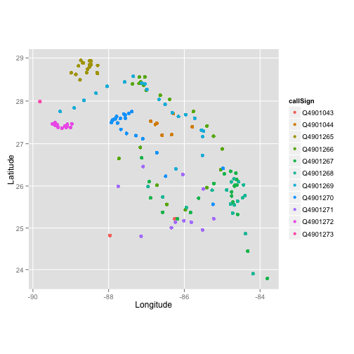

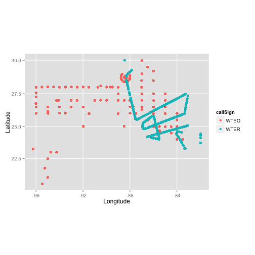

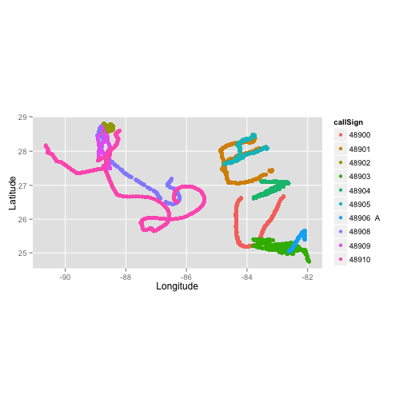

```r
qplot(Longitude, Latitude, colour=callSign, data=floats) + coord_map()
qplot(Longitude, Latitude, colour=callSign, data=boats) + coord_map()
qplot(Longitude, Latitude, colour=callSign, data=gliders) + coord_map()
```

### Add a map

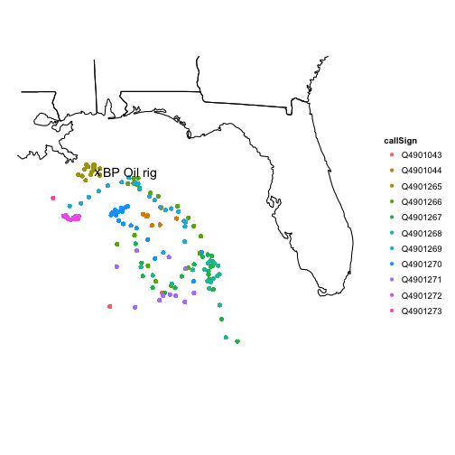

```r
ggplot() +   # plot without a default data set
 geom_path(data=states, aes(x=long, y=lat, group=group)) +
 geom_point(data=floats, aes(x=Longitude, y=Latitude, colour=callSign)) +
 geom_point(aes(x, y), shape="x", size=5, data=rig) +
 geom_text(aes(x, y), label="BP Oil rig", shape="x", size=5, data=rig, hjust = -0.1) +
 xlim(c(-91, -80)) +
 ylim(c(22,32)) + coord_map() + new_theme_empty
```

### Get fancy

[figure not shown]

```r
gm <- get_googlemap(center = c(lon = -86.77, lat = 26.99), zoom=6)
ggmap(gm) + geom_point(data=floats, aes(x=Longitude, y=Latitude, colour=callSign))
```

### Pairs Plot

A scatterplot matrix allows all pairs of numeric variables to be examined, in a manner similar to looking at a correlation matrix. The generalized pairs plot, places appropriate plots of pairs of variables in the cells depending on the type of variable.

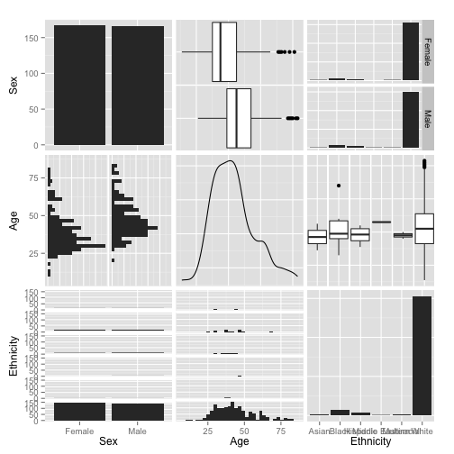

```r
library(GGally)
ggpairs(acting, columns=c(2,6,8))
```

### Parallel coordinate plots

```r
iris2 <- iris
iris2$alphaLevel <- c("setosa" = 0.2,
  "versicolor" = 0, "virginica" = 0.5)[iris2$Species]
gpd <- ggparcoord(data = iris2,
  columns = 1:4,
  groupColumn = 5, order = "anyClass",
  showPoints = TRUE,
  title = "Iris Data",
  alphaLines = "alphaLevel")
```

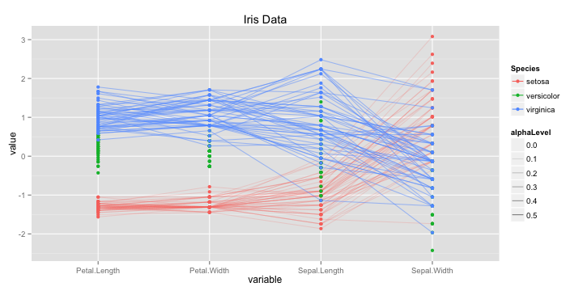

### Arranging multiple plots on a page

```r
acting$Decade <- floor(acting$Year/10)*10
library(dplyr)
as <- summarise(group_by(acting, Decade), age=mean(Age, na.rm=T),
        white=length(Ethnicity[Ethnicity=="White"])/length(Ethnicity),
        sex=length(Sex[Sex=="Male"])/length(Sex),
        orientation=length(SexualOrientation[SexualOrientation=="Bisexual"])/
          length(SexualOrientation))
p1 <- qplot(Decade, age, data=as) + geom_smooth(se=F)
p2 <- qplot(Decade, white, data=as) + geom_smooth(se=F)
p3 <- qplot(Decade, sex, data=as) + geom_smooth(se=F)
p4 <- qplot(Decade, orientation, data=as) + geom_smooth(se=F)
```

### Plot it

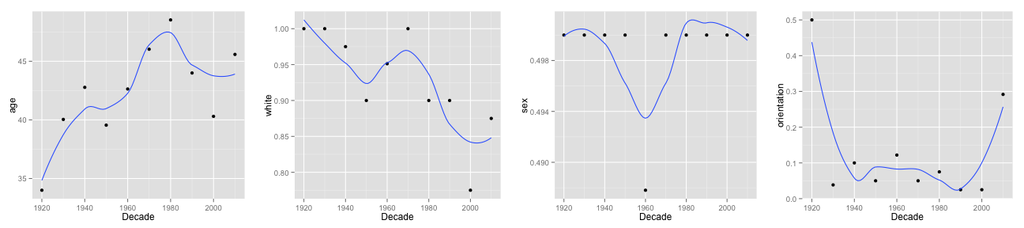

```r
library(gridExtra)
grid.arrange(p1, p2, p3, p4, ncol=4)
```

### Summary

- Grammar is good!
- Almost anything is possible
- R Graphics Cookbook by Winston Chang http://www.cookbook-r.com/Graphs/
- http://stackoverflow.com